# Comparison of calibrated projection score equating and equipercentile score equating

Sangdon Lim

# Introduction

*Scale linking* vs *Score equating*

- a *scale* is an instrument composed of multiple items
- a *score* is a value that quantifies responses to an instrument
  - raw score
  - T-score
  - $\theta$

# Scale linking

*Scale link* is achieved when

- a set of item parameters $\xi$
- is on the same metric with
- another set of anchor item parameters $\xi'$

Notation

$\xi$ : the set of item parameters (e.g. difficulty, …)

# Scale linking

Suppose we have a response dataset $\mathbf{X}$ with

- items $a_1 ... a_{10}$ from scale $a$

Through item parameter calibration on $\mathbf{X}$, we can obtain

- item parameters $\xi_a$ for items $a_1 ... a_{10}$

# Scale linking

Suppose we have another dataset $\mathbf{X'}$ with

- items $a_1 ... a_{10}$ from scale $a$
- items $b_1 ... b_{10}$ from scale $b$

Let the item parameters from this dataset be denoted by $\xi'_a$ and $\xi'_b$

Without conversion, $\xi'_a$ is on a different metric compared to $\xi_a$

- because $\mathbf{X'}$ comes from a different ability range compared to $\mathbf{X}$

# Scale linking

Scale link is achieved when $\xi'_a$ is on the same metric with $\xi_a$

- this makes $\xi'_a$ comparable to $\xi_a$
- this makes $\xi'_b$ from $\mathbf{X'}$ interpretable on the (unobtainable) metric of $\xi_b$ as if it was from $\mathbf{X}$

# Scale linking

Scale linking methods include

*Linear transformation*

- find a function $f: \xi' \rightarrow \xi$ that converts $\xi'_a$ to the metric of $\xi_a$
- once $f$ is determined, $f$ can be used to convert $\xi'_b$ to $\xi_b$
- Haebara method (1980)
- Stocking-Lord method (1983)

# Scale linking

Scale linking methods include

*Fixed-parameter calibration*

- Item calibration phase on $\mathbf{X'}$ is modified
- $\xi' = \{\xi'_a, \xi'_b\}$ is estimated subject to the constraint $\xi'_a = \xi_a$
- $\xi' = \{\xi'_a, \xi'_b\}$ is obtained so that $\xi'_a$ is on the same metric with $\xi_a$
- This achieves scale link
- Further metric conversions should not be done
- Because further altering the metric breaks link

# Score equating

*Score equating* is achieved when

- a set of score levels for one scale
- is mapped to corresponding score levels on another scale

# Score equating

Suppose that we have

- scale $a$ with scores $x_a$ ranging in $[0, 10]$
- scale $b$ with scores $x_b$ ranging in $[0, 100]$

Scores $x_a$ and $x_b$ are on different metrics

# Score equating

Given a score $x_a = 5$

- one may define a corresponding score level $\hat{x}_b$ on instrument $b$
- so that $\hat{x}_b$ can be compared to $x_b$ in the same metric

Score equating is the process of determining

- the map $f: x_a \rightarrow \hat{x}_b$ for all $x_a$ levels

# Score equating

Equipercentile equating is a method of score equating

- scores of scale $a$ are mapped onto the percentile $p$ metric
- and then onto the metric of scale $b$
- so that $x_a \rightarrow p \rightarrow \hat{x}_b$

The process does not involve item parameters

- only involves observed scores $x_a$ and $x_b$

# Score equating

Equipercentile equating may be modified to get standardized scores

- scores of scale $a$ are mapped onto the percentile $p$ metric
- and then onto the $\theta$ metric
- so that $x_a \rightarrow p \rightarrow \theta$

To accomplish this,

- scale $b$ scores are first mapped onto the $\theta$ metric
- using a presupplied set of item parameters for scale $b$
- the item parameters may be obtained from free calibration or converted with scale linking as needed

# Score equating

The end product of score equating is a crosswalk table

| Scale A (raw) | Scale B (raw) | Scale B (theta) | Scale B (T-score) |
| --- | --- | --- | --- |
| 0 | 5.0 | -0.781 | 42.189 |
| 1 | 14.1 | -0.416 | 45.835 |
| 2 | 23.2 | -0.108 | 48.918 |
| 3 | 32.3 | 0.159 | 51.589 |
| 4 | 41.4 | 0.394 | 53.944 |
| 5 | 50.5 | 0.605 | 56.052 |
| 6 | 59.6 | 0.796 | 57.958 |
| 7 | 68.7 | 0.970 | 59.698 |
| 8 | 77.8 | 1.130 | 61.299 |
| 9 | 86.9 | 1.278 | 62.781 |
| 10 | 96.0 | 1.416 | 64.161 |

# Summary

*Scale linking* is about the metrics of item parameters

*Score equating* is about the metrics of observed scores

# Calibrated projection

*Calibrated projection* [CP; Thissen et al. (2011)] is a procedure for mapping the score levels between two scales

- maps each score level in scale $a$ onto a corresponding $\theta$ in scale $b$
- Lord-Wingersky recursion (1984) is the standard method
- the objective is related to the metrics of scores
- not to the metrics of item parameters
- thus CP can be considered as a score equating method

# Calibrated projection

Suppose that we have a response dataset $\mathbf{X}$ with

- scale $a$ with items $a_1 ... a_{10}$
- scale $b$ with items $b_1 ... b_{10}$

A 2-factor IRT model is fitted onto the response dataset $\mathbf{X}$

# Calibrated projection

```r
model <- mirt.model("
  F1  =  1-10  # free estimation for scale a items
  F2  = 11-20  # free estimation for scale b items
  COV = F1*F2
")

cp_calib <- mirt(X, model, itemtype = "graded")
```

First discrimination parameter

- is freely estimated for scale $a$ items; fixed at $0$ for other scales

Second discrimination parameter

- is freely estimated for scale $b$ items; fixed at $0$ for other scales

Other item parameters are freely estimated as usual

The correlation between factors are freely estimated

# Calibrated projection

Calibrated model can be used to produce a crosswalk table

- Lord-Wingersky recursion (1984) is the standard method
- requires multidimensional extension to apply to CP

In Thissen et al. (2011), the authors presented a table

- raw scores in PedsQL scale are mapped onto T-scores in PAIS scale

# Calibrated projection

Table 4 Thissen et al. (2011)

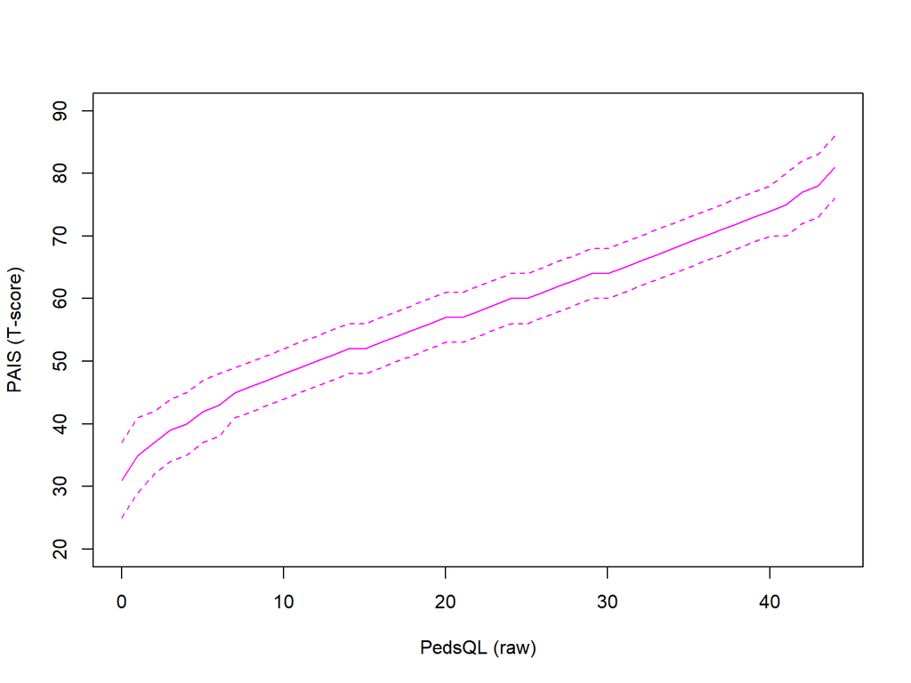

# Calibrated projection

Table 4 (reproduced)

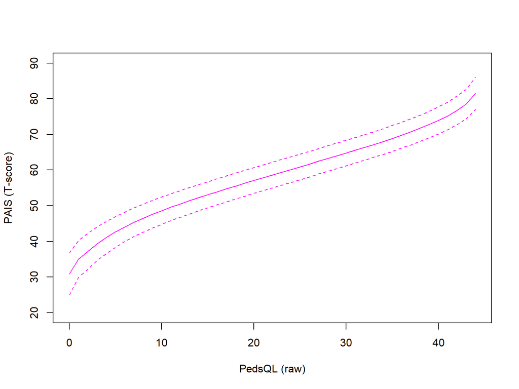

# Calibrated projection

Step 1. Read in item parameters

(code blocks are scrollable)

```r
# demo/CP_demo_read.r
# read origin tables and create item objects

d2 <- read.csv(file.path(root, "data/table2.csv"))
d3 <- read.csv(file.path(root, "data/table3.csv"))
d  <- cbind(
  d2[order(d2[, 1]), ],
  d3[order(d3[, 1]), -1]
)

ipar <- d[, -c(1, 14)]
colnames(ipar)[9:12] <- paste0("d", 1:4)
ipar <- ipar[, c(1:2, 9:12)]

itempool <- generate.mirt_object(ipar, itemtype = "graded")
```

- Tables 2, 3 from Thissen et al. (2011)

# Calibrated projection

Step 2. Initialize theta grid for multidimensional integration

```r
# module/module_grid.r
# creates quadrature points over two-dimensional space

nd         <- 2
theta      <- seq(-4.5, 4.5, .2)
theta_grid <- as.matrix(expand.grid(theta, theta))
n_grid     <- dim(theta_grid)[1]
```

- Used -4.5(0.2)4.5 for each dimension, fully crossed
- Total # of quadrature points: 2116
- Should use other ways of integration with more dimensions

# Calibrated projection

Step 3. Function for getting category probability

```r
# module/module_computeResponseProbability.r
# function for computing category response probability
# at a given theta point

computeResponseProbability <- function(
  itempool, theta, item_idx, score_level
) {

  n_examinees <- nrow(theta)
  p           <- rep(NA, n_examinees)

  probs       <- mirt::probtrace(itempool, Theta = theta)
  itemname    <- colnames(itempool@Data$data)[item_idx]
  use_these   <- sprintf("%s.P.%s", itemname, score_level + 1)
  probs       <- probs[, use_these]

  return(probs)

}
```

- input: item pool, 2D $\theta$, item ID, score level on that item
- output: a single probability value
- necessary for multidimensional Lord-Wingersky recursion

# Calibrated projection

Step 4. Lord-Wingersky recursion (multidimensional extension)

```r
# module/module_LWrecursion.r
# function for performing Lord-Wingersky recursion
# this obtains likelihoods of each score level over quadrature points

LWrecursion <- function(itempool, use_items, theta_grid) {

  L_init <- TRUE

  for (item_idx in use_items) {

    new_max_value_of_item <- itempool@Data$K[item_idx] - 1
    new_possible_values   <- 0:new_max_value_of_item

    P <- list()
    for (v in new_possible_values) {
      P[[as.character(v)]] <-
        computeResponseProbability(itempool, theta_grid, item_idx, v)
    }

    if (L_init) {

      L <- P
      old_possible_values <- new_possible_values
      L_init <- FALSE

    } else {

      map_values <- expand.grid(old_possible_values, new_possible_values)

      map_L <- do.call(rbind, L[as.character(map_values[, 1])])
      map_P <- do.call(rbind, P[as.character(map_values[, 2])])

      map_lls <- map_L * map_P

      tmp <- aggregate(map_lls, by = list(apply(map_values, 1, sum)), sum)

      tmp_lls   <- tmp[, -1]
      tmp_value <- tmp[, 1]

      L <- list()
      for (i in 1:nrow(tmp)) {
        L[[as.character(tmp_value[i])]] <-
          tmp_lls[i, ]
      }

      old_possible_values <- tmp[, 1]

    }

  }

  return(L)

}
```

# Calibrated projection

Step 4. Lord-Wingersky recursion (multidimensional extension)

- input: item pool, items to use, theta grid
- output: for each possible score level, likelihood value of obtaining the score level at each quadrature point

```r
# demo/CP_demo_LW.r
# likelihood values for 11 items in PedsQL instrument
# the test score ranges from 0-44

pedsql_items <- 18:28
L <- LWrecursion(itempool, pedsql_items, theta_grid)
```

Use PedsQL items

- range of possible score levels: $[0, 44]$
- likelihood of obtaining score $0$ at each of 2116 quadrature points
- likelihood of obtaining score $1$ at each of 2116 quadrature points
- …
- likelihood of obtaining score $44$ at each of 2116 quadrature points

# Calibrated projection

Step 5. Compute EAP estimates from likelihoods

- input: likelihoods, theta grid, latent correlation
- output: EAP estimates and covariance matrix for each score level

```r
# module/module_LtoEAP.r
# converts likelihoods obtained from Lord-Wingersky recursion
# into two-dimensional EAP estimates

LtoEAP <- function(L, theta_grid, sigma) {

  nd  <- dim(theta_grid)[2]
  tmp <- list()

  for (i in 1:length(L)) {

    num <- matrix(0, 1, nd)
    den <- 0

    for (j in 1:n_grid) {
      term_T <- theta_grid[j, , drop = FALSE]
      term_L <- as.numeric(L[[i]][j])
      term_W <- dmvn(term_T, rep(0, nd), sigma)
      num <- num + (term_T * term_L * term_W)
      den <- den + (term_L * term_W)
    }

    th <- num / den

    num <- matrix(0, nd, nd)
    den <- 0

    for (j in 1:n_grid) {
      term_T <- theta_grid[j, , drop = FALSE]
      term_C <- (term_T - th)
      term_V <- t(term_C) %*% term_C
      term_L <- as.numeric(L[[i]][j])
      term_W <- dmvn(term_T, rep(0, nd), sigma)
      num <- num + (term_V * term_L * term_W)
      den <- den + (term_L * term_W)
    }

    COV <- num / den

    tmp[[names(L)[i]]]$EAP <- th
    tmp[[names(L)[i]]]$COV <- COV

  }

  return(tmp)

}
```

# Calibrated projection

Step 5. Compute EAP estimates from likelihoods

- estimated correlation $.96$ is used here

```r
# demo/CP_demo_EAP.r
# converts likelihood values of PedsQL instrument
# into two-dimensional theta estimates

est_cor     <- .96
sigma       <- diag(nd)
sigma[2, 1] <- est_cor
sigma[1, 2] <- est_cor

EAP <- LtoEAP(L, theta_grid, sigma)
```

# Calibrated projection

Step 5. Compute EAP estimates from likelihoods

- the equations were adapted from Bryant et al. (2005)

# Calibrated projection

Given a $k$-dimensional vector $\theta$,

the $k$-dimensional EAP estimate given a score level $x$ is

$$\mathrm{E}(\theta|x) =
\frac{\int{\theta \mathrm{L}(x|\theta) f(\theta,\Sigma) d\theta}}
{\int{\mathrm{L}(x|\theta) f(\theta,\Sigma) d\theta}}$$

approximated by

$$\mathrm{E}(\theta|x) =
\frac{\sum{\theta \mathrm{L}(x|\theta) f(\theta,\Sigma)}}
{\sum{\mathrm{L}(x|\theta) f(\theta,\Sigma)}}$$

- $\mathrm{L}(x|\theta)$: previously computed likelihood
- $f(\theta, \Sigma)$: multivariate normal density value
- $\Sigma$: the 2D correlation matrix

The summation is taken over all $\theta$ grid

# Calibrated projection

Given a $k$-dimensional vector $\theta$,

the $k$-dimensional EAP covariance given a score level $x$ is

$$\mathrm{C}(\theta|x) =
\frac{\int{\mathrm{C}(\theta) \mathrm{L}(x|\theta) f(\theta,\Sigma)
d\theta}}
{\int{\mathrm{L}(x|\theta) f(\theta,\Sigma) d\theta}}$$
approximated by

$$\mathrm{C}(\theta|x) =
\frac{\sum{\mathrm{C}(\theta) \mathrm{L}(x|\theta) f(\theta,\Sigma)}}
{\sum{\mathrm{L}(x|\theta) f(\theta,\Sigma)}}$$

- $\mathrm{C}(\theta)$: variance-covariance matrix $(\theta - \theta_\mathrm{EAP})(\theta - \theta_\mathrm{EAP})'$

The summation is taken over all $\theta$ grid

# Calibrated projection

Step 6. Aggregate into a table

```r
# module/module_EAPtoTABLE.r
# function for converting EAP estimates into a table

EAPtoTABLE <- function(EAP, dimension, tscore) {

  eap  <- lapply(EAP, function(x) x$EAP[dimension])
  se   <- lapply(EAP, function(x) sqrt(x$COV[dimension, dimension]))
  eap  <- do.call(c, eap)
  se   <- do.call(c, se)
  if (tscore) {
    eap <- (eap*10) + 50
    se  <- se*10
  }
  x <- as.numeric(names(eap))
  o <- cbind(x, eap, se)
  o <- as.data.frame(o)

  return(o)

}
```

```r
# demo/CP_demo_TABLE.r
# converts two-dimensional theta estimates into a table

o <- EAPtoTABLE(EAP, TRUE, dimension = 1)
```

# Calibrated projection

It should be emphasized that the focus of CP method is not the item parameters

- focus is on the latent correlation and its use in producing the table

The correlation between two factors represent the relationship between two scales

- using this information, obtaining a multidimensional EAP $\theta$ estimate yields a $\theta$ estimate on scale $a$ and scale $b$ simultaneously

# Motivation

Advantage of CP over EQP:

- CP takes the correlation between constructs explicitly into account

If the latent correlation is perfect, CP and EQP should perform similar in terms of producing T-scores

As latent correlation decreases, CP should perform better than EQP

Question: by how much?

# Study objective

Equipercentile equating method vs. calibration projection method

- compare performance in producing corresponding $\theta$ values
- varied correlation between the constructs underlying each scale

# Method: Item parameters

Derived from PROMIS Depression - CES-D dataset in `PROsetta`

- includes 731 response rows and 48 items
- (after removing missing data)
- 20 items on scale $a$ (CES-D scale)
- 28 items on scale $b$ (PROMIS Depression scale)

# Method: Item parameters

1D IRT model was fitted on the dataset

- graded response model for all items

Obtained 1D parameters were converted to 2D parameters

- to be used in response data generation
- CES-D items were loaded onto dimension 1
- PROMIS items were loaded onto dimension 2

# Method: Simulee & response data

1000 2D $\theta$ values were sampled from MVN with specified correlation

Response dataset $\mathbf{X}$ was generated from item parameters and 2D theta values

# Method: EQP

Equipercentile method was performed on $\mathbf{X}$

- smoothing was not applied
- since obtaining $\theta$ values from equipercentile method requires item parameters, item parameters were estimated by performing free calibration on $\mathbf{X}$

# Method: CP

Calibrated projection method was performed on $\mathbf{X}$

- used 2D model
- factor 1: 20 CES-D items
- factor 2: 28 PROMIS items
- latent correlation: free estimation with upper bound of .999
- to avoid singular structures

# Method: 1D pattern scoring

- used 1D item parameters for 48 items obtained for performing EQP as basis
- used PROMIS item parameters to obtain EAP estimates from the PROMIS part of $\mathbf{X}$
- to serve as best-case reference

# Performance criteria

From $\mathbf{X}$, CES-D raw score was computed for each simulee

- CES-D raw score was mapped to PROMIS $\theta$ using the crosswalk table from CP or EQP
- produced PROMIS $\theta$ was compared to true PROMIS $\theta$
- used RMSE

# Simulation

- factor correlation was $0.95(-0.05)0.50$
- repeated 20 trials each

# Results

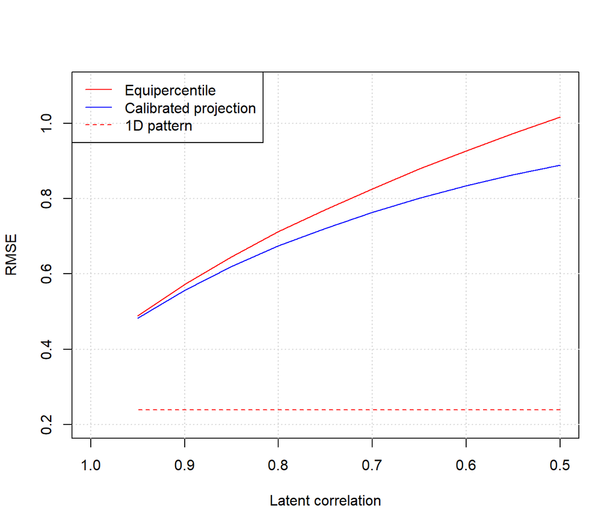

# Discussion

Calibrated projection explicitly accounts for latent correlation between measured constructs

- CP provides better crosswalk table
- since CP uses multidimensional modeling, CP can equate more than two scales simultaneously
- technical issue: multidimensional integration is time-consuming

# References

Bryant, D. U., Smith, A. K., Alexander, S. G., Vaughn, K., & Canali, K. G. (2005). *Expected A Posteriori Estimation of Multiple Latent Traits: (518612013-445)*. American Psychological Association. https://doi.org/10.1037/e518612013-445

Haebara, T. (1980). Equating logistic ability scales by a weighted least squares method. *Japanese Psychological Research*, *22*(3), 144–149.

Lord, F. M., & Wingersky, M. S. (1984). Comparison of IRT True-Score and Equipercentile Observed-Score "Equatings". *Applied Psychological Measurement*, *8*(4), 453–461. https://doi.org/10.1177/014662168400800409

Stocking, M. L., & Lord, F. M. (1983). Developing a common metric in item response theory. *Applied Psychological Measurement*, *7*(2), 201–210.

Thissen, D., Varni, J. W., Stucky, B. D., Liu, Y., Irwin, D. E., & DeWalt, D. A. (2011). Using the PedsQL™ 3.0 asthma module to obtain scores comparable with those of the PROMIS pediatric asthma impact scale (PAIS). *Quality of Life Research*, *20*(9), 1497–1505. https://doi.org/10.1007/s11136-011-9874-y